# Q & K Box 15.1

### Do biplots with scaling=1 (plot distances match euclidean dists - angles between variables irrelevant) and scaling=2

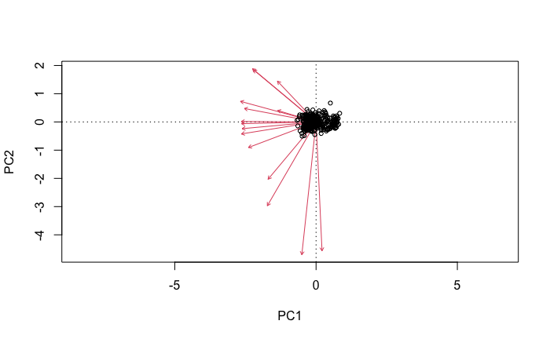

```r
biplot(wu1.rda, scaling=1)
```

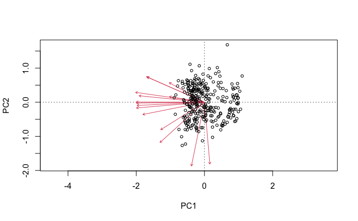

```r
# now with scaling=2 - this is more useful
biplot(wu1.rda, scaling=2)
```

[figure not shown]

```r
# try with ordiplot (default scale=2)
ordiplot(wu1.rda, choices=c(1,2), display='sites', type='none')
```

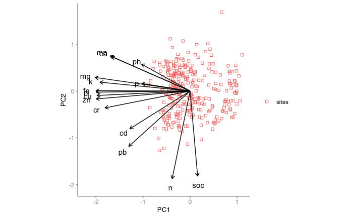

```r
#points (wu1.rda, col = wu$group, pch = wu$group)
autoplot(wu1.rda, shape = wu$group,
         label = TRUE, label.size = 3,  loadings = TRUE,
         loadings.label = TRUE, loadings.label.size = 3, scale= 0
         ) +
#geom_point(data = wu1.rda,aes(RDA1,RDA2,colour = landuse),size=2,alpha=0.5)
scale_shape_manual(values=c(0,1,2))+
  theme_qk()+
  theme(
    legend.title = element_blank()
  )
```

Try varimax rotation

```r
principal(wu.cor, n.obs=300, nfactors=3, rotate="varimax")
```

```
Principal Components Analysis
Call: principal(r = wu.cor, nfactors = 3, rotate = "varimax", n.obs = 300)
Standardized loadings (pattern matrix) based upon correlation matrix
```

|  | RC1 | RC3 | RC2 | h2 | u2 | com |
| --- | --- | --- | --- | --- | --- | --- |
| ca | 0.50 | 0.78 | -0.16 | 0.8845862670 | 0.11541373297 | 1.814966177 |
| cd | 0.40 | 0.46 | 0.51 | 0.6298741304 | 0.37012586961 | 2.878746042 |
| cr | 0.89 | 0.13 | 0.17 | 0.8281099624 | 0.17189003763 | 1.115708342 |
| cu | 0.89 | 0.31 | 0.09 | 0.8979038091 | 0.10209619091 | 1.251239908 |
| fe | 0.94 | 0.26 | 0.02 | 0.9433137003 | 0.05668629974 | 1.155280467 |
| mg | 0.85 | 0.47 | -0.05 | 0.9344486336 | 0.06555136638 | 1.565272066 |
| mn | 0.73 | 0.40 | -0.29 | 0.7806095962 | 0.21939040379 | 1.922850150 |
| ni | 0.90 | 0.31 | 0.05 | 0.9158885279 | 0.08411147214 | 1.234324412 |
| pb | 0.72 | -0.13 | 0.50 | 0.7866978982 | 0.21330210184 | 1.866604911 |
| zn | 0.81 | 0.46 | 0.17 | 0.9027438339 | 0.09725616609 | 1.686574808 |

[output cut: 5 more lines]

```
                       RC1  RC3  RC2
SS loadings           6.91 2.81 2.32
Proportion Var        0.46 0.19 0.15
Cumulative Var        0.46 0.65 0.80
Proportion Explained  0.57 0.23 0.19
Cumulative Proportion 0.57 0.81 1.00

Mean item complexity =  1.5
Test of the hypothesis that 3 components are sufficient.

The root mean square of the residuals (RMSR) is  0.05
 with the empirical chi square  141  with prob <  6.2e-08

Fit based upon off diagonal values = 0.99
```

### Do PCA on covariance matrix

```r
options(digits=10)
wu2.rda <- rda(wu[,c('ca','cd','cr','cu','fe','mg','mn','ni','pb','zn','ph','soc','n','p','k')],scale=FALSE)
summary(wu2.rda)
```

```
Call:
rda(X = wu[, c("ca", "cd", "cr", "cu", "fe", "mg", "mn", "ni",      "pb", "zn", "ph", "soc", "n", "p", "k")], scale = FALSE)

Partitioning of variance:
               Inertia Proportion
Total         163243.5          1
Unconstrained 163243.5          1

Eigenvalues, and their contribution to the variance

Importance of components:
                               PC1          PC2          PC3          PC4          PC5          PC6          PC7          PC8          PC9         PC10         PC11         PC12
Eigenvalue            7.571096e+04 6.145057e+04 2.589640e+04 1.392029e+02 3.397364e+01 5.4839052446 4.100869e+00 2.234922e+00 4.691284e-01 4.395120e-02 3.221747e-02 1.674771e-02
Proportion Explained  4.637916e-01 3.764350e-01 1.586366e-01 8.527314e-04 2.081163e-04 0.0000335934 2.512118e-05 1.369073e-05 2.873795e-06 2.692370e-07 1.973584e-07 1.025934e-07
Cumulative Proportion 4.637916e-01 8.402266e-01 9.988632e-01 9.997159e-01 9.999240e-01 0.9999576051 9.999827e-01 9.999964e-01 9.999993e-01 9.999996e-01 9.999998e-01 9.999999e-01
                              PC13         PC14         PC15
Eigenvalue            1.450067e-02 6.185779e-03 2.163316e-03
Proportion Explained  8.882845e-08 3.789295e-08 1.325208e-08
Cumulative Proportion 9.999999e-01 1.000000e+00 1.000000e+00

Scaling 2 for species and site scores
* Species are scaled proportional to eigenvalues
* Sites are unscaled: weighted dispersion equal on all dimensions
* General scaling constant of scores:  83.58469892


Species scores

              PC1           PC2           PC3          PC4          PC5           PC6
ca   -0.038595809   0.002017012  -0.023045195  0.013473576  0.010415212 -0.0089143350
cd   -0.004510752  -0.006196526  -0.004868552  0.003126177  0.002106561  0.0008584689
cr   -0.856727213  -0.515659161  -1.199186325  1.339777180 -0.856488858  0.2072352642
cu   -0.740714876  -0.241886719  -0.596965607  0.590718444 -0.080309121 -0.1314547156
fe   -0.076060817  -0.019602987  -0.084885388  0.061504487 -0.012178313 -0.0099022818
mg   -0.053056126  -0.007411519  -0.047819584  0.036755088  0.001394533 -0.0150870233
mn  -28.786303812   7.776712046 -28.141684083 -0.198351098 -0.010234228  0.0022411978
ni   -0.773536414  -0.243422510  -0.936863446  0.843239387 -0.239651673 -0.4063610324
pb   -0.104549245  -0.230101578  -0.192721520  0.155868054 -0.062054647 -0.0173378963
zn   -2.539059988  -1.077063718  -1.705498417  1.738731426  0.807316492  0.0854777771
ph   -0.044874321   0.007909935  -0.047695277  0.032207264  0.015631342 -0.0319952870
```

[output cut: 161 more lines]

```
sit153  -4.87833526  1.700532e+00  -0.45678694   2.59260902   2.77447488   1.534697846
sit154  -4.36128494  2.377166e+00  -3.39642898   0.70978199  -0.23242297  -2.019306910
sit155  -3.28446948  8.136850e-01  -3.54663391   5.27699674   5.40403406  -3.326022354
sit156  -1.64209209  7.957919e+00  -5.42067190   0.74681315  -1.14972180   1.968235264
sit157  -3.17175691  1.915948e+00  -2.07255098   3.05793287   4.56613213  -2.584028870
sit158   3.04884112  7.799896e+00  -1.03715780   4.68844364  -0.69708367   5.280793723
sit159  -0.06020073 -2.540949e+00  -2.98152173  -6.67482537  -4.29674713  11.503972289
sit160  -5.21288132 -5.328755e-01   3.01391937   0.52514056   3.18921573   3.351058586
sit161  -4.30170105  2.693235e+00   4.33621051   2.86132228   1.87127883   4.456855629
sit162  -1.26798292  5.854461e+00   1.93247619   1.29583539   1.17093528  -3.217325581
sit163  -0.51033130  1.616064e+00  -2.96427251   1.71850283  -2.00899657   5.555637409
sit164   3.46770661 -2.975760e+00  -3.65774179   4.23471230   4.82406344  -4.606390289
sit165  -4.43944295  4.328100e+00   0.22671581   2.98499767   0.73921126  -1.881616261
sit166   1.68558343 -2.366311e+00   6.41854873   1.00352615  -0.98598125   5.118569477
 [ reached getOption("max.print") -- omitted 134 rows ]
```

```r
scores(wu2.rda, choices=c(1:2), display='species', scaling = 0)
```

```
                 PC1              PC2
ca  -6.780347384e-04  0.0000393311470
cd  -7.924296995e-05 -0.0001208304870
cr  -1.505061899e-02 -0.0100552056778
cu  -1.301256365e-02 -0.0047167216016
fe  -1.336204061e-03 -0.0003822526200
mg  -9.320674429e-04 -0.0001445224866
mn  -5.057055320e-01  0.1516436533552
ni  -1.358915845e-02 -0.0047466690877
pb  -1.836676627e-03 -0.0044869147439
zn  -4.460512507e-02 -0.0210024334415
ph  -7.883329614e-04  0.0001542414662
soc  1.895087365e-04 -0.0005959401288
n    1.458232008e-01 -0.9551859159818
p   -8.487752702e-01 -0.2530145375865
k   -8.766107829e-04 -0.0001728739345
attr(,"const")
[1] 83.58469892
```

```r
wu2.cov <- cov(wu[,c('ca','cd','cr','cu','fe','mg','mn','ni','pb','zn','ph','soc','n','p','k')])
wu2.vec <- eigen(wu2.cov)
print(wu2.vec)
```

```
eigen() decomposition
$values
 [1] 7.571096416e+04 6.145057283e+04 2.589639838e+04 1.392028752e+02 3.397363594e+01 5.483905245e+00 4.100869117e+00 2.234922443e+00 4.691284042e-01 4.395119845e-02 3.221747328e-02
[12] 1.674770957e-02 1.450066788e-02 6.185779103e-03 2.163315794e-03

$vectors
                  [,1]             [,2]             [,3]             [,4]            [,5]            [,6]             [,7]             [,8]             [,9]            [,10]
 [1,] -6.780347384e-04  0.0000393311470 -6.922323577e-04 -0.0055201384769 -0.008637504172 -0.018400734874 -0.0159564304042  4.011773460e-02  0.1305127770191  2.358755549e-01
 [2,] -7.924296995e-05 -0.0001208304870 -1.462417343e-04 -0.0012807979215 -0.001747005622  0.001772028899 -0.0018347739091 -2.059612034e-03  0.0156931091544 -5.064962310e-02
 [3,] -1.505061899e-02 -0.0100552056778 -3.602119960e-02 -0.5489081279879  0.710300125573  0.427769559371 -0.0869096303802  3.851289227e-02  0.0181713634362  8.838008219e-05
 [4,] -1.301256365e-02 -0.0047167216016 -1.793167321e-02 -0.2420179714088  0.066601659012 -0.271345352274  0.8813569536956  2.921626930e-01  0.0170453778822 -1.524475172e-02
 [5,] -1.336204061e-03 -0.0003822526200 -2.549790169e-03 -0.0251984533206  0.010099672729 -0.020440028621  0.0099304023521 -1.999311944e-02 -0.0423233347599  6.484384812e-01
 [6,] -9.320674429e-04 -0.0001445224866 -1.436406292e-03 -0.0150585984553 -0.001156509173 -0.031142235151 -0.0096317468330  2.913024508e-02  0.0103792938220  4.226873791e-01
 [7,] -5.057055320e-01  0.1516436533552 -8.453208633e-01  0.0812646548203  0.008487411819  0.004626221351 -0.0007583159275 -3.178455173e-05 -0.0002333980917 -7.564578423e-04
 [8,] -1.358915845e-02 -0.0047466690877 -2.814153605e-02 -0.3454760689039  0.198747026207 -0.838799711269 -0.3506505149522 -5.302457207e-02 -0.0852221187215 -5.716368926e-02
```

[output cut: 23 more lines]

```r
# get true loadings as correlations
wu2.load <- eigen.loadings(wu2.vec)
print(wu2.load)
```

```
                  [,1]             [,2]             [,3]            [,4]            [,5]            [,6]            [,7]             [,8]             [,9]            [,10]
 [1,]   -0.18656549874  9.749886941e-03   -0.11139650872 -0.065128949812 -0.050345340726 -0.043090361635 -0.032312733340  5.997463717e-02  0.0893920496079  4.945022770e-02
 [2,]   -0.02180419877 -2.995294256e-02   -0.02353374333 -0.015111400538 -0.010182755519  0.004149691118 -0.003715527757 -3.079049346e-03  0.0107486732263 -1.061846106e-02
 [3,]   -4.14127194335 -2.492607666e+00   -5.79666037095 -6.476252374556  4.140119776314  1.001739611808 -0.175997239984  5.757545293e-02  0.0124461026639  1.852847868e-05
 [4,]   -3.58048826931 -1.169238780e+00   -2.88562903548 -2.855431322846  0.388200474252 -0.635429478088  1.784800954882  4.367732047e-01  0.0116748819544 -3.195992244e-03
 [5,]   -0.36766490415 -9.475746608e-02   -0.41032136044 -0.297302107278  0.058867869077 -0.047865926612  0.020109663316 -2.988902779e-02 -0.0289885000292  1.359421520e-01
 [6,]   -0.25646418614 -3.582600589e-02   -0.23115164191 -0.177667771765 -0.006740934327 -0.072928075100 -0.019504867889  4.354871722e-02  0.0071090844086  8.861446942e-02
 [7,] -139.14803985809  3.759128803e+01 -136.03205900011  0.958795082296  0.049470498819  0.010833564658 -0.001535635460 -4.751681462e-05 -0.0001598612356 -1.585879154e-04
 [8,]   -3.73914193411 -1.176662530e+00   -4.52863670922 -4.076074114246  1.158434954549 -1.964279315214 -0.710088428182 -7.926991648e-02 -0.0583711421858 -1.198410514e-02
 [9,]   -0.50537306064 -1.112271439e+00   -0.93158266871 -0.753439356435  0.299961487150 -0.083808407471  0.558793812868 -1.405515594e+00  0.1191508898916  1.447545259e-03
[10,]  -12.27337912799 -5.206340703e+00   -8.24408591228 -8.404728559842 -3.902429020871  0.413184867636 -0.172631765891 -3.268308054e-02 -0.0083984554406 -2.757512522e-03
[11,]   -0.21691474462  3.823526572e-02   -0.23055076528 -0.155684374694 -0.075559219409 -0.154659712582 -0.186809168948  2.265147019e-01  0.6645065476220 -4.874164101e-03
[12,]    0.05214451404 -1.477289457e-01    0.00920806957  0.005814642296 -0.008716442710  0.031089321709  0.009367011163 -1.634615016e-02  0.0194467954777 -2.008861607e-02
[13,]   40.12416568566 -2.367831959e+02  -41.08530125198  0.399372879114  0.019653527676 -0.003370267140 -0.001450073379  5.269317042e-03 -0.0002234907133  2.735793959e-05
[14,] -233.54582388473 -6.272034567e+01   74.64632596154  0.165594895050  0.080461541929 -0.004718711818 -0.004116313402 -1.020983521e-03  0.0001125557051  7.483685780e-06
```

[output cut: 17 more lines]

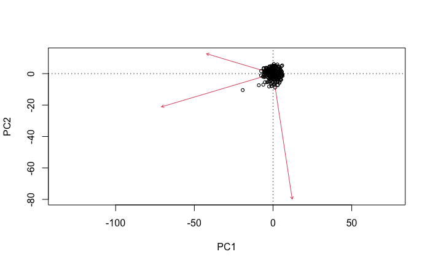

```r
biplot(wu2.rda, scaling=1)
```

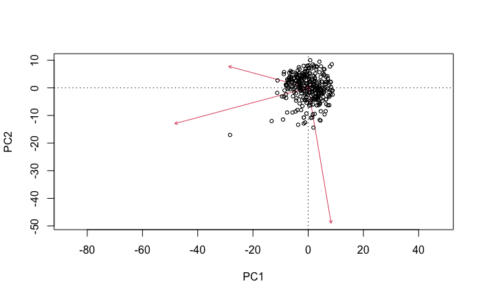

```r
biplot(wu2.rda, scaling=2)
```

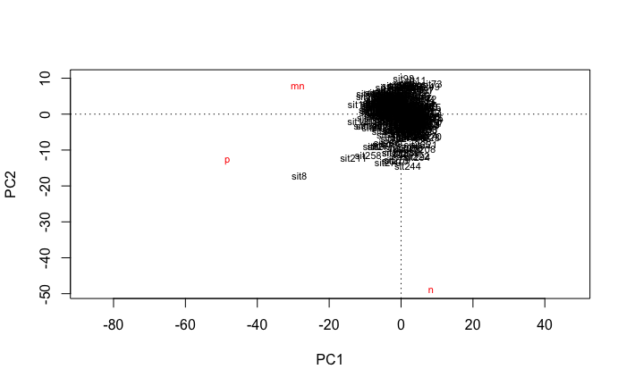

```r
ordiplot(wu2.rda, choices=c(1,2), type='text')
```

### Do pca on correlation & covariance matrices with princomp

Correlation matrix

```r
wu1.pca <- princomp(~ca+cd+cr+cu+fe+mg+mn+ni+pb+zn+ni+ph+soc+n+p+k, cor=T, data=wu)
summary(wu1.pca)
```

```
Importance of components:
                             Comp.1       Comp.2        Comp.3        Comp.4        Comp.5        Comp.6        Comp.7        Comp.8        Comp.9       Comp.10        Comp.11
Standard deviation     2.9272302613 1.5400496837 1.04570938871 0.95162944936 0.70441478608 0.56339607069 0.55034751910 0.49710666852 0.46271997591 0.39706231423 0.331349891270
Proportion of Variance 0.5712451335 0.1581168685 0.07290054171 0.06037324059 0.03308001272 0.02116100883 0.02019215945 0.01647433599 0.01427398507 0.01051056543 0.007319516696
Cumulative Proportion  0.5712451335 0.7293620020 0.80226254376 0.86263578435 0.89571579707 0.91687680590 0.93706896536 0.95354330135 0.96781728642 0.97832785185 0.985647368544
                              Comp.12        Comp.13       Comp.14        Comp.15
Standard deviation     0.274024190279 0.241732174358 0.22294524608 0.179056382494
Proportion of Variance 0.005005950457 0.003895629608 0.00331363885 0.002137412541
Cumulative Proportion  0.990653319001 0.994548948609 0.99786258746 1.000000000000
```

```r
loadings(wu1.pca)
```

```
Loadings:
    Comp.1 Comp.2 Comp.3 Comp.4 Comp.5 Comp.6 Comp.7 Comp.8 Comp.9 Comp.10 Comp.11 Comp.12 Comp.13 Comp.14 Comp.15
ca   0.270  0.226  0.354         0.121         0.175  0.247  0.204  0.533   0.429   0.200   0.221   0.140   0.136
cd   0.207 -0.248  0.325        -0.847        -0.143 -0.135
cr   0.292 -0.111 -0.246  0.181        -0.119 -0.353 -0.452  0.273 -0.151   0.343           0.463          -0.170
cu   0.320        -0.132                             -0.150  0.166  0.267  -0.671   0.521                   0.128
fe   0.324        -0.205                                     0.164          0.107  -0.295  -0.273  -0.690   0.391
mg   0.327                              0.263               -0.136                  0.110  -0.346  -0.170  -0.777
mn   0.275  0.230               -0.185  0.185  0.653         0.259 -0.514                           0.127
ni   0.323        -0.146  0.170               -0.199                        0.138          -0.568   0.606   0.286
pb   0.211 -0.363 -0.293               -0.668  0.347  0.278 -0.195  0.117   0.110                          -0.142
zn   0.323               -0.158         0.128                       0.224  -0.355  -0.731   0.253   0.249  -0.105
ph   0.167  0.176  0.616  0.443  0.172 -0.445                      -0.253  -0.210                  -0.110
soc        -0.558  0.252         0.316  0.211  0.395 -0.513 -0.178  0.111
n          -0.575  0.161         0.156  0.222 -0.174  0.553  0.340 -0.312
p    0.166         0.249 -0.836  0.182 -0.247 -0.171               -0.213   0.128          -0.112
k    0.310                              0.222         0.149 -0.746 -0.234           0.153   0.334           0.246

               Comp.1 Comp.2 Comp.3 Comp.4 Comp.5 Comp.6 Comp.7 Comp.8 Comp.9 Comp.10 Comp.11 Comp.12 Comp.13 Comp.14 Comp.15
SS loadings     1.000  1.000  1.000  1.000  1.000  1.000  1.000  1.000  1.000   1.000   1.000   1.000   1.000   1.000   1.000
Proportion Var  0.067  0.067  0.067  0.067  0.067  0.067  0.067  0.067  0.067   0.067   0.067   0.067   0.067   0.067   0.067
Cumulative Var  0.067  0.133  0.200  0.267  0.333  0.400  0.467  0.533  0.600   0.667   0.733   0.800   0.867   0.933   1.000
```

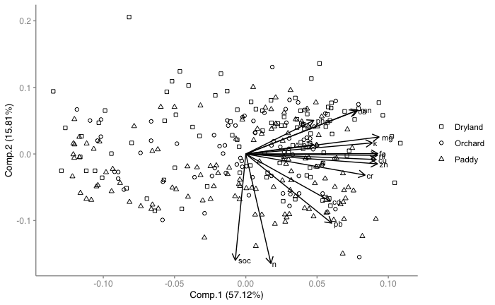

```r
autoplot(wu1.pca, data=wu, shape = "landuse", scale=1,
         loadings = TRUE, loadings.colour = 'black',
         loadings.label = TRUE, loadings.label.size = 3,
         loadings.label.colour="black", loadings.label.hjust=-0.25
         )+
scale_shape_manual(values=c(0,1,2))+
  theme_qk()+
  theme(
    legend.title = element_blank()
  )
```

PCA on covariance matrix with princomp

```r
wu2.pca <- princomp(~ca+cd+cr+cu+fe+mg+mn+ni+pb+zn+ni+ph+soc+n+p+k, cor=F, data=wu)
summary(wu2.pca)
```

```
Importance of components:
                               Comp.1         Comp.2        Comp.3          Comp.4          Comp.5          Comp.6          Comp.7          Comp.8          Comp.9         Comp.10
Standard deviation     274.6972775170 247.4787619002 160.655149471 1.177874635e+01 5.8189681630445 2.337867738e+00 2.021682357e+00 1.492472010e+00 6.837869865e-01 2.092957106e-01
Proportion of Variance   0.4637915538   0.3764349982   0.158636612 8.527314177e-04 0.0002081162956 3.359340305e-05 2.512117605e-05 1.369072715e-05 2.873795017e-06 2.692370233e-07
Cumulative Proportion    0.4637915538   0.8402265521   0.998863164 9.997158954e-01 0.9999240117365 9.999576051e-01 9.999827263e-01 9.999964170e-01 9.999992908e-01 9.999995601e-01
                               Comp.11         Comp.12         Comp.13         Comp.14         Comp.15
Standard deviation     1.791928617e-01 1.291970738e-01 1.202178536e-01 7.851853182e-02 4.643387504e-02
Proportion of Variance 1.973583636e-07 1.025934134e-07 8.882844597e-08 3.789295426e-08 1.325207794e-08
Cumulative Proportion  9.999997574e-01 9.999998600e-01 9.999999489e-01 9.999999867e-01 1.000000000e+00
```

```r
loadings(wu2.pca)
```

```
Loadings:
    Comp.1 Comp.2 Comp.3 Comp.4 Comp.5 Comp.6 Comp.7 Comp.8 Comp.9 Comp.10 Comp.11 Comp.12 Comp.13 Comp.14 Comp.15
ca                                                           0.131  0.236   0.197   0.170   0.835   0.401
cd                                                                                                         -0.995
cr                        0.549 -0.710 -0.428
cu                        0.242         0.271 -0.881  0.292
fe                                                                  0.648   0.621  -0.237  -0.333   0.125
mg                                                                  0.423                   0.300  -0.848
mn   0.506  0.152  0.845
ni                        0.345 -0.199  0.839  0.351
pb                                            -0.276 -0.940  0.174
zn                        0.712  0.670 -0.176
ph                                                    0.152  0.970                         -0.139
soc                                                                        -0.137  -0.955   0.242
n   -0.146 -0.955  0.255
p    0.849 -0.253 -0.464
k                                                                   0.574  -0.738          -0.149   0.318

               Comp.1 Comp.2 Comp.3 Comp.4 Comp.5 Comp.6 Comp.7 Comp.8 Comp.9 Comp.10 Comp.11 Comp.12 Comp.13 Comp.14 Comp.15
SS loadings     1.000  1.000  1.000  1.000  1.000  1.000  1.000  1.000  1.000   1.000   1.000   1.000   1.000   1.000   1.000
Proportion Var  0.067  0.067  0.067  0.067  0.067  0.067  0.067  0.067  0.067   0.067   0.067   0.067   0.067   0.067   0.067
Cumulative Var  0.067  0.133  0.200  0.267  0.333  0.400  0.467  0.533  0.600   0.667   0.733   0.800   0.867   0.933   1.000
```

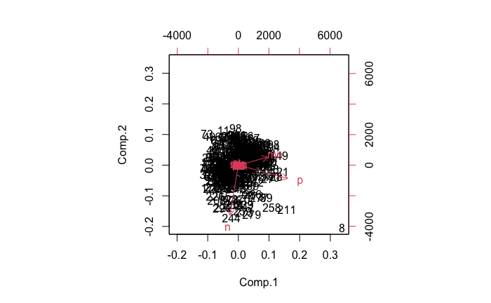

```r
# do biplot
biplot(wu2.pca)
```

### Repeat plot with ggplot2 in progress

get variable loadings as correlations (unscaled variable scores)

scores(wu1.rda, choices=c(1:4), display=‘species’,scaling = 0)

do biplots with scaling=1 (plot distances match euclidean dists - angles between variables irrelevant) and scaling=2

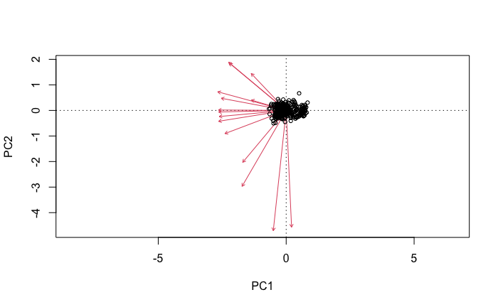

```r
biplot(wu1.rda, scaling=1)
```

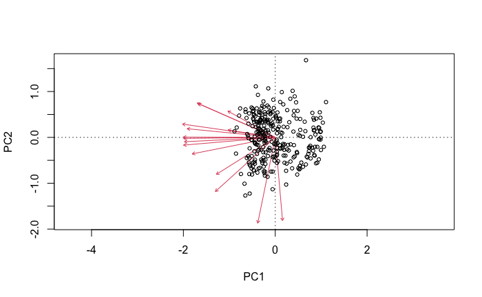

```r
biplot(wu1.rda, scaling=2)
```

```r
p<-autoplot(wu1.rda, scale=1)
#ordiplot(wu1.rda, choices=c(1,2), display='sites', type='none')
#points (wu1.rda, col = wu$group, pch = wu$group )
```

do pca on correlation matrix with princomp

```r
f15_3a<-autoplot(wu1.pca, data=wu, shape = "landuse", scale=1,colour=sc,
         loadings = TRUE, loadings.colour = 'black',
         loadings.label = TRUE, loadings.label.size = 3,
         loadings.label.colour="black", loadings.label.repel=TRUE
         )+
scale_shape_manual(values=c(0,1,2))+
  theme_qk()+
  theme(
    legend.title = element_blank()
  )
```

## Figures

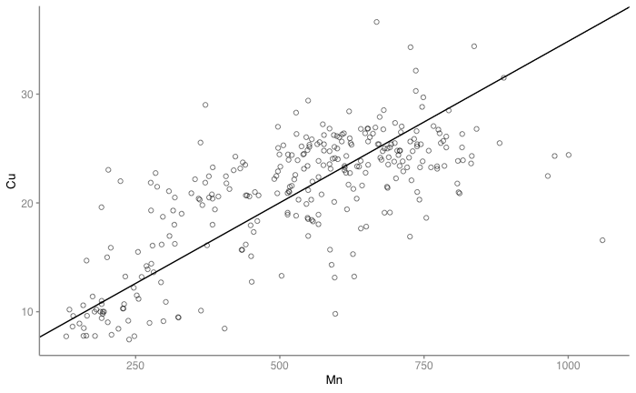

```r
f15_1<-ggplot(wu)+
  geom_point(aes(x=mn,y=cu), alpha=0.5,shape=1)+
  geom_abline(intercept=wu1.rma$regression.results[3,2],
              slope=wu1.rma$regression.results[3,3], colour="black")+
  labs(x="Mn", y="Cu")+
  theme_qk()
f15_1
```

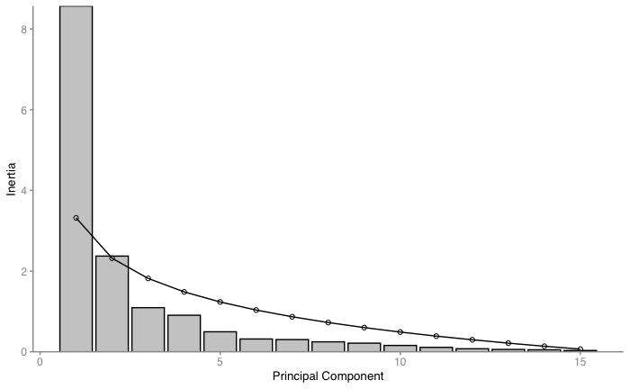

```r
#Ugly little workaround to get single file with eigenvalues and broken stick into simple file
f1<-as.data.frame(bstick(wu1.rda))
a2<-as.data.frame(wu1.rda$CA$eig)
a2<-cbind(a2,f1)
a2$PC<-row.names(a2)
names(a2)[names(a2) == 'wu1.rda$CA$eig'] <- 'eig'
names(a2)[names(a2) == 'bstick(wu1.rda)'] <- 'bs'
a2$PC <- factor(a2$PC, levels = a2$PC)
a2$ID <- seq_along(a2[,1])
f15_2<-ggplot(a2)+
  geom_bar(aes(x=ID,y=eig),stat="identity", color=lc, fill=lf)+
  scale_y_continuous(expand = c(0,0))+
  geom_line(aes(x=ID,y=bs))+
  geom_point(aes(x=ID,y=bs), shape=1)+
  labs(y="Inertia",x="Principal Component")+
  theme_qk()
f15_2
```

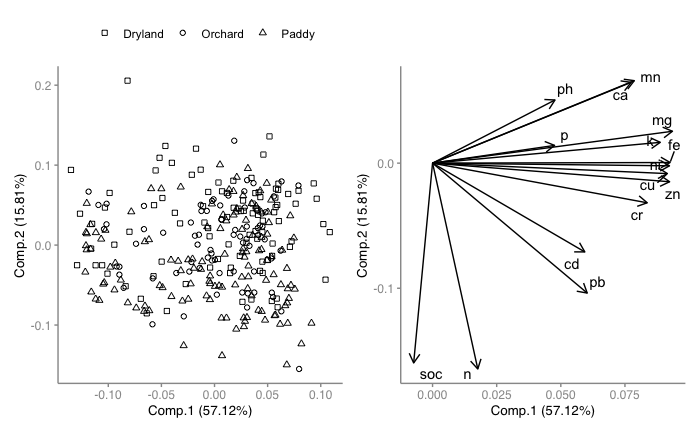

```r
p1<-autoplot(wu1.pca, data=wu, shape='landuse')
p1<-p1+scale_shape_manual(values=c(0,1,2))+
  theme_qk()+
  theme(
    legend.position = "top",
    legend.title=element_blank()
  )
p2<-autoplot(wu1.pca, shape=FALSE,label=FALSE,
         loadings=TRUE, loadings.label=TRUE,
         loadings.label.colour="black",
         loadings.colour="black",
         loadings.label.repel=TRUE
)+
  theme_qk()
f15_3<-p1+p2
f15_3
```